# Understanding Language Endangerment

Policy implications from Northeast India

Ritwiz Sarma

Madras School of Economics

December 28, 2023

## The central problem

> “Over 40 percent of the world’s approximately 7,000 languages are at risk of disappearing.”

Source: [Endangered Languages Project](https://www.endangeredlanguages.com/about/)

Language endangerment is about more than a speaker count. It is also about **which language people can use at home, in school, and in public life**.

## Three working definitions

- **Endangered language:** a language at risk of dying out because it lacks speakers.
- **Language shift:** speakers move from their mother tongue toward a dominant language.
- **Majority tongue:** the area’s default language for education and public affairs.

## Endangerment is concentrated in the Northeast

The Northeast accounts for **43 of 117** languages on the SPPEL endangered-languages list used in the source presentation.

| Zone | Languages |
| --- | --- |
| North East | 43 |
| Northern | 25 |
| Southern | 20 |
| East Central | 15 |
| Andaman and Nicobar | 9 |
| West Central | 5 |

Source: [SPPEL Endangered Languages list](https://static.pib.gov.in/WriteReadData/specificdocs/documents/2025/jul/doc2025731596601.pdf).

## How many languages are there in India?

| Source and year | Reported count |
| --- | --- |
| Linguistic Survey of India, 1927 | 179 languages and 544 dialects |
| Census, 1961 | 1,652 languages, later revised to 1,100 |
| Census, 1971 | 109 languages with more than 10,000 speakers |
| Census, 2011 | 121 languages |
| People’s Linguistic Survey of India, 2013 | 780–880 languages |

## Scheduled and non-scheduled languages

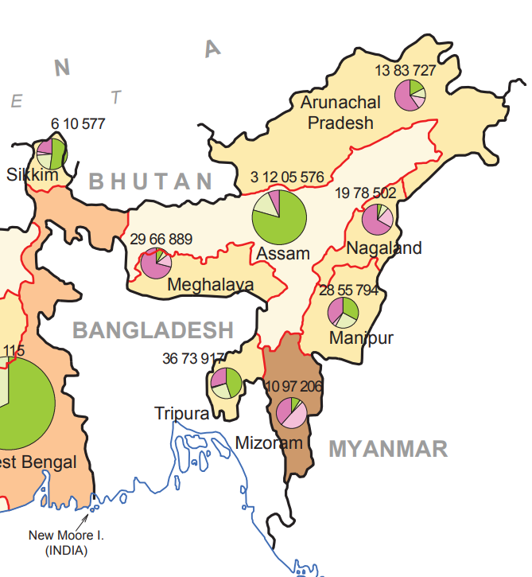

Scheduled and non-scheduled language speakers across Northeast India.

The source map distinguishes **scheduled** and **non-scheduled** language speakers in rural and urban areas.

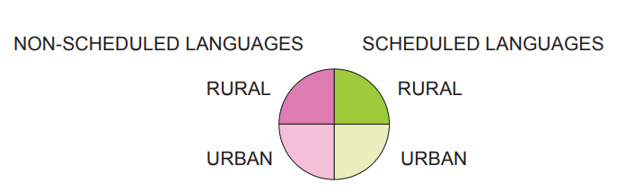

Legend for the rural and urban shares in the map.

Source: *Language Atlas 2011*, Census of India. Pie sizes indicate population; slices indicate language category and residence.

## Speaker shares have shifted

**26.7%**

Growth in scheduled-language speaker share in Arunachal Pradesh during the 1990s

**223%**

Growth in scheduled-language speaker share in Mizoram during the 1990s

**6.53%**

Growth in scheduled-language speaker share in Assam during the 2000s

**20.5%**

Growth in scheduled-language speaker share in Nagaland during the 2000s

Percentage changes refer to shares, not percentage-point changes.

## Why shift away from a mother tongue?

**A language can be numerically large yet functionally marginal**—or locally dominant while marginal in wider institutions.

> “I want her to go to law school. I do not want her to be a maid when she grows up. She should know English and Marathi.”

Tulu-speaking mother quoted in Padharipande (1992), as reproduced in the source presentation. Numeric/functional distinction attributed there to Srivastava (1984).

## The Tai Khamti case

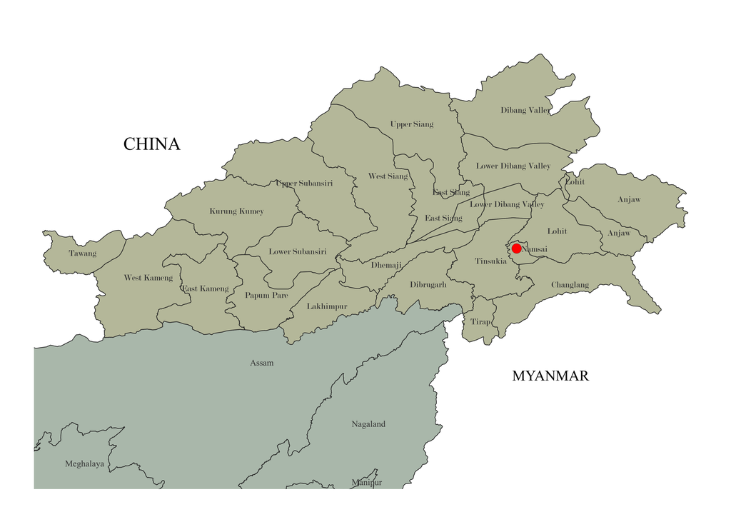

Namsai marked in red.

- Resident in Namsai District
- Two-level social stratification
- A majority or minority language at different subnational levels
- Spoken across economic strata

**Speaker-count estimates**

| Source | Speakers |
| --- | --- |
| Census 2011 | 12,890 |
| Gaur et al. (2022) | 5,000 |
| Morey (2005) | 7,500 |

## Methodology

### Interviews

- Ten semi-structured interviews
- Government workers, teachers, independent artistes, and clergymen
- Respondents aged 25–56; all literate and educated up to graduate level

### Analytical framework

Fishman’s (1991) *reversing language shift* framework guides the case study. Interviews examine:

- Language identification and maintenance
- Indigenous knowledge and documentation
- Linguistic culture, including honorifics
- Narrative forms

## Findings: identification and knowledge

### Community identification

- Hindi versus Assamese in everyday speech
- Language maintenance from elders to younger speakers
- “We learn English only in school” — Namchoom
- Tai Khamti Heritage and Literary Society
- “Two or three generations from now, Khamti will still be spoken.”

### Indigenous knowledge

- No dictionary; script digitalisation in progress — Mannoi
- No textbooks; teachers use Myanmarese material
- Indigenous context and its uniqueness (Abbi, 2021)
- Some words cannot be translated and may die with the language

## Findings: honorifics and narratives

### Honorifics

- Honorifics carry over into majority-tongue speech without translation.
- Translation becomes onerous when requested.
- They exemplify “linguistic culture” (Schiffman, 1996).

### Narrative forms

- Almost all have heard folktales; few can remember them.
- Stories are unique to the culture, not translations.
- Songs are performed at festivals and distributed physically and online.

## What community-led work needs

### Cultural programmes

- Ceremonial use reaffirms identity.
- Programmes provide a forum for the community.
- Festivals need resources.

### Local capacity

- Include community stakeholders in research and decisions.
- Provide documentation training and tools.

### Data collection

- Repositories require technical infrastructure.
- Gaur et al. (2022) report outdated primary data.

### Reference materials

- Their absence limits language teaching and maintenance.
- Community initiative needs support for resource-intensive work.

## Fund, follow, facilitate

[figure not shown]

- **Fund** documentation, archiving, local libraries, native scholars, and heritage festivals.
- **Follow** speaker numbers for all languages and priorities set by indigenous leaders and scholars.
- **Facilitate** local organisations, training, and language teaching.

## Closing thought

> “Only a community can keep its language alive. No governmental or non-governmental initiative is sufficient in this regard.”

Gaur, C. R., Dey, S., & Mamta, K. (2022). *Tribal and Indigenous Languages of India*. UNESCO.